# QALL401: Data Analysis for Researchers

### F2: The poorest half lags behind: Bottom 50%, middle 40% and top 10% income shares across the world in 2021

```r
df_f2 <- read_excel("./data/WIR2022s.xlsx", sheet = "data-F2")
df_f2
```

| year | iso | Bottom 50% | Middle 40% | Top 10% |
| --- | --- | --- | --- | --- |
| 2021 | Europe | 0.1891 | 0.4531 | 0.3578 |
| 2021 | East Asia | 0.1391 | 0.4268 | 0.4341 |
| 2021 | North America | 0.1322 | 0.4105 | 0.4573 |
| 2021 | Russia & Central Asia | 0.1466 | 0.3863 | 0.4671 |
| 2021 | South & South East Asia | 0.1233 | 0.3283 | 0.5484 |
| 2021 | Latin America | 0.1016 | 0.3445 | 0.5539 |
| 2021 | Sub-Saharan Africa | 0.0892 | 0.3537 | 0.5571 |
| 2021 | MENA | 0.0900 | 0.3288 | 0.5812 |

```r
df_f2 %>% pivot_longer(cols = 3:5, names_to = "group", values_to = "value")
```

| year | iso | group | value |
| --- | --- | --- | --- |
| 2021 | Europe | Bottom 50% | 0.1891 |
| 2021 | Europe | Middle 40% | 0.4531 |
| 2021 | Europe | Top 10% | 0.3578 |
| 2021 | East Asia | Bottom 50% | 0.1391 |
| 2021 | East Asia | Middle 40% | 0.4268 |
| 2021 | East Asia | Top 10% | 0.4341 |
| 2021 | North America | Bottom 50% | 0.1322 |
| 2021 | North America | Middle 40% | 0.4105 |
| 2021 | North America | Top 10% | 0.4573 |
| 2021 | Russia & Central Asia | Bottom 50% | 0.1466 |

[output cut: 14 more lines]

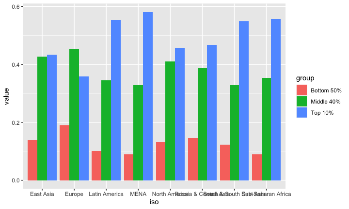

```r
df_f2 %>% pivot_longer(cols = 3:5, names_to = "group", values_to = "value") %>%
  ggplot(aes(x = iso, y = value, fill = group)) +
  geom_col(position = "dodge")
```

### Pivot data from long to wide:

[`pivot_wider()`](https://tidyr.tidyverse.org/reference/pivot_wider.html) In Console: vignette(“pivot”)

```
pivot_wider(data,
  names_from = <name of the column (or columns) to get the name of the output column>,
  values_from = <name of the column to get the value of the output>)
```

| year | iso | group | value |
| --- | --- | --- | --- |
| 2021 | Europe | Bottom 50% | 0.1891 |
| 2021 | Europe | Middle 40% | 0.4531 |
| 2021 | Europe | Top 10% | 0.3578 |
| 2021 | East Asia | Bottom 50% | 0.1391 |
| 2021 | East Asia | Middle 40% | 0.4268 |
| 2021 | East Asia | Top 10% | 0.4341 |
| 2021 | North America | Bottom 50% | 0.1322 |
| 2021 | North America | Middle 40% | 0.4105 |
| 2021 | North America | Top 10% | 0.4573 |
| 2021 | Russia & Central Asia | Bottom 50% | 0.1466 |

[output cut: 14 more lines]

```
pivot_wider(data, names_from = group, values_from = value)
```

### Practice: F4 and F13

F4 and F13 are similar. Please use `pivot_longer` to tidy the data and create charts.

- **References**: https://ds-sl.github.io/data-analysis/wir2022.nb.html

#### Done Last Week

- F12: Female share in global labor incomes, 1990-2020
- F14: Global carbon inequality, 2019. Group contribution to world emissions (%)

### F3: Top 10/Bottom 50 income gaps across the world, 2021

```r
df_f3 <- read_excel("./data/WIR2022s.xlsx", sheet = "data-F3")
df_f3
```

| year | Country | T10B50 |
| --- | --- | --- |
| 2021 | United Arab Emirates | 19.204010 |
| 2021 | Afghanistan | 11.669610 |
| 2021 | Albania | 8.989956 |
| 2021 | Armenia | 10.957560 |
| 2021 | Angola | 32.092700 |
| 2021 | Argentina | 13.180250 |
| 2021 | Austria | 7.679657 |
| 2021 | Australia | 10.393100 |
| 2021 | Azerbaijan | 9.630005 |
| 2021 | Bosnia and Herzegovina | 9.321850 |

[output cut: 167 more lines]

### F3: Top 10/Bottom 50 income gaps across the world, 2021 - Original

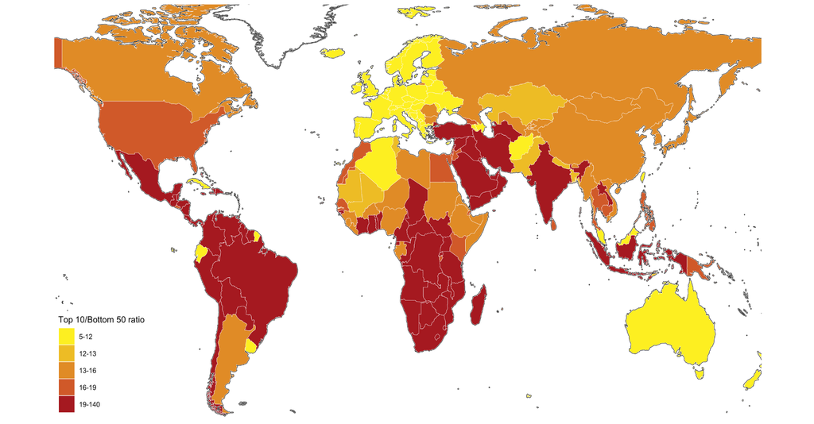

- To 10 / Bottom 50 ratio has 5 classes: 5-12, 12-13, 13-16, 16-19, 19-140

```r
df_f3$T10B50 %>% summary()
```

```
##    Min. 1st Qu.  Median    Mean 3rd Qu.    Max.
##   5.394  10.958  15.676  17.635  19.838 139.591
```

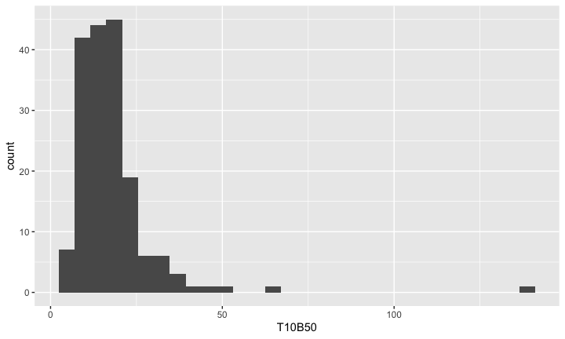

```r
df_f3 %>% ggplot() + geom_histogram(aes(T10B50))
```

```r
df_f3 %>% arrange(desc(T10B50))
```

| year | Country | T10B50 |
| --- | --- | --- |
| 2021 | Oman | 139.590900 |
| 2021 | South Africa | 63.098640 |
| 2021 | Namibia | 49.030030 |
| 2021 | Zambia | 44.420860 |
| 2021 | Central African Republic | 42.524850 |
| 2021 | Mozambique | 38.944060 |
| 2021 | Swaziland | 38.112220 |
| 2021 | Botswana | 36.492850 |
| 2021 | Angola | 32.092700 |
| 2021 | Yemen | 31.963060 |

[output cut: 167 more lines]

```r
df_f3 %>%
  mutate(`Top 10 Bottom 50 Ratio` = cut(T10B50,breaks = c(5, 12, 13, 16, 19,140),
                                        include.lowest = FALSE))
```

| year | Country | T10B50 | Top 10 Bottom 50 Ratio |
| --- | --- | --- | --- |
| 2021 | United Arab Emirates | 19.204010 | (19,140] |
| 2021 | Afghanistan | 11.669610 | (5,12] |
| 2021 | Albania | 8.989956 | (5,12] |
| 2021 | Armenia | 10.957560 | (5,12] |
| 2021 | Angola | 32.092700 | (19,140] |
| 2021 | Argentina | 13.180250 | (13,16] |
| 2021 | Austria | 7.679657 | (5,12] |
| 2021 | Australia | 10.393100 | (5,12] |
| 2021 | Azerbaijan | 9.630005 | (5,12] |
| 2021 | Bosnia and Herzegovina | 9.321850 | (5,12] |

[output cut: 167 more lines]

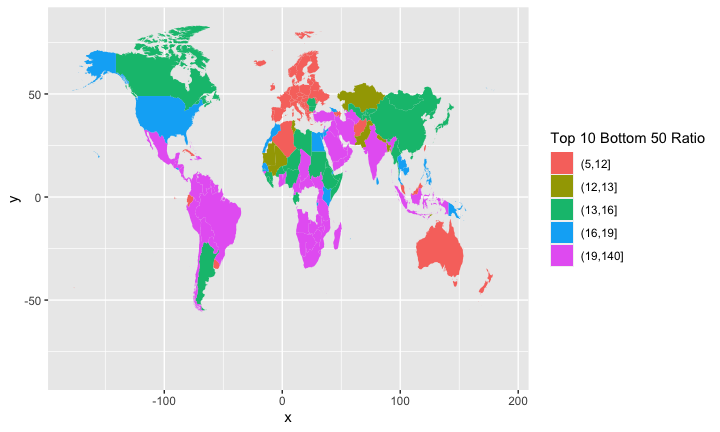

```r
world_map <- map_data("world")
df_f3 %>% mutate(`Top 10 Bottom 50 Ratio` = cut(T10B50,breaks = c(5, 12, 13, 16, 19,140),
                                        include.lowest = FALSE)) %>%
  ggplot(aes(map_id = Country)) +
  geom_map(aes(fill = `Top 10 Bottom 50 Ratio`), map = world_map) +
  expand_limits(x = world_map$long, y = world_map$lat)
```

```r
world_map_wir <- world_map
world_map_wir$region[
  world_map_wir$region=="Democratic Republic of the Congo"]<-"DR Congo"
world_map_wir$region[world_map_wir$region=="Republic of Congo"]<-"Congo"
world_map_wir$region[world_map_wir$region=="Ivory Coast"]<-"Cote dIvoire"
world_map_wir$region[world_map_wir$region=="Vietnam"]<-"Viet Nam"
world_map_wir$region[world_map_wir$region=="Russia"]<-"Russian Federation"
world_map_wir$region[world_map_wir$region=="South Korea"]<-"Korea"
world_map_wir$region[world_map_wir$region=="UK"]<-"United Kingdom"
world_map_wir$region[world_map_wir$region=="Brunei"]<-"Brunei Darussalam"
world_map_wir$region[world_map_wir$region=="Laos"]<-"Lao PDR"
world_map_wir$region[world_map_wir$region=="Cote dIvoire"]<-"Cote d'Ivoire"
world_map_wir$region[world_map_wir$region=="Cape Verde"]<- "Cabo Verde"
world_map_wir$region[world_map_wir$region=="Syria"]<- "Syrian Arab Republic"
world_map_wir$region[world_map_wir$region=="Trinidad"]<- "Trinidad and Tobago"
world_map_wir$region[world_map_wir$region=="Tobago"]<- "Trinidad and Tobago"
```

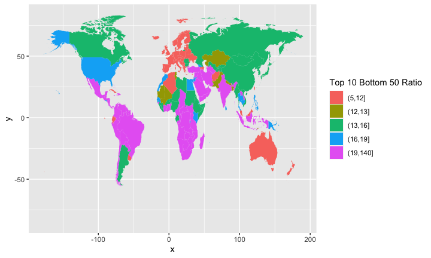

```r
df_f3 %>% mutate(`Top 10 Bottom 50 Ratio` =
    cut(T10B50, breaks = c(5, 12, 13, 16, 19,140), include.lowest = FALSE)) %>%
  ggplot(aes(map_id = Country)) +
  geom_map(aes(fill = `Top 10 Bottom 50 Ratio`),
    map = world_map_wir) +
    expand_limits(x = world_map_wir$long, y = world_map_wir$lat)
```

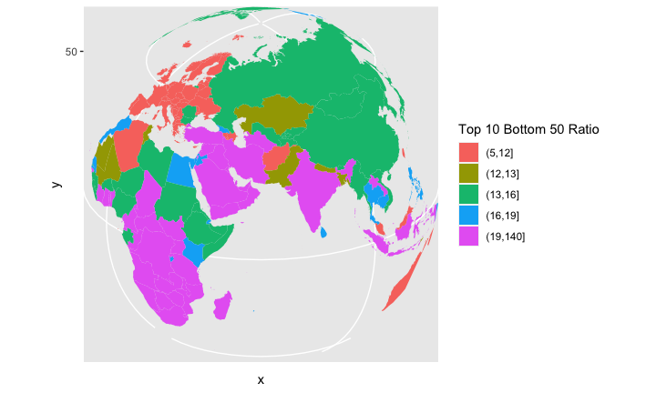

```r
df_f3 %>% mutate(`Top 10 Bottom 50 Ratio` =
    cut(T10B50,breaks = c(5, 12, 13, 16, 19,140), include.lowest = FALSE)) %>%
  ggplot(aes(map_id = Country)) + geom_map(aes(fill = `Top 10 Bottom 50 Ratio`),
    map = world_map_wir) + expand_limits(x = world_map_wir$long, y = world_map_wir$lat) +
  coord_map("orthographic", orientation = c(25, 60, 0))
```

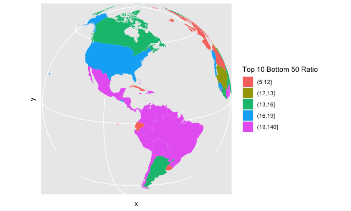

```r
df_f3 %>% mutate(`Top 10 Bottom 50 Ratio` =
  cut(T10B50,breaks = c(5, 12, 13, 16, 19,140), include.lowest = FALSE)) %>%
  ggplot(aes(map_id = Country)) + geom_map(aes(fill = `Top 10 Bottom 50 Ratio`),
    map = world_map_wir) + expand_limits(x = world_map_wir$long, y = world_map_wir$lat) +
  coord_map("orthographic", orientation = c(15, -80, 0))
```

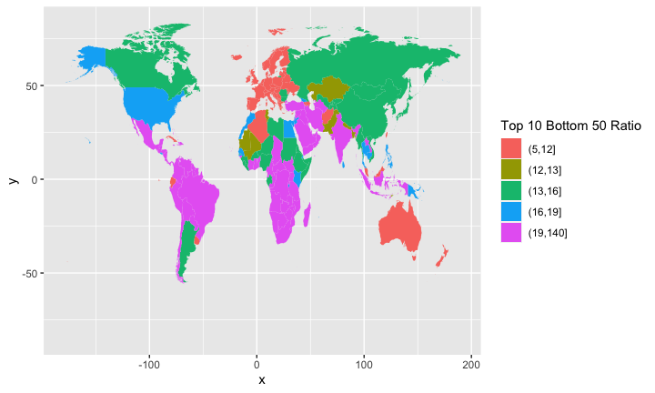

```r
df_f3 %>% mutate(`Top 10 Bottom 50 Ratio` =
  cut(T10B50,breaks = c(5, 12, 13, 16, 19,140), include.lowest = FALSE)) %>%
  ggplot(aes(map_id = Country)) + geom_map(aes(fill = `Top 10 Bottom 50 Ratio`),
    map = world_map_wir) +
  expand_limits(x = world_map_wir$long, y = world_map_wir$lat)
```

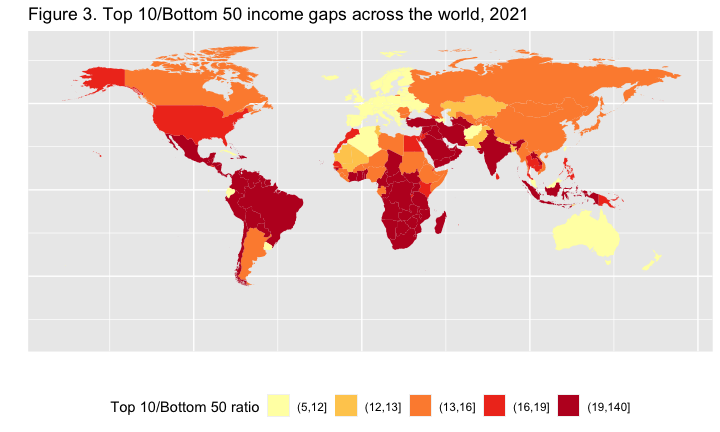

```r
df_f3 %>%
  mutate(`Top 10 Bottom 50 Ratio` =
        cut(T10B50,breaks = c(5, 12, 13, 16, 19,140), include.lowest = FALSE)) %>%
  ggplot(aes(map_id = Country)) +
  geom_map(aes(fill = `Top 10 Bottom 50 Ratio`), map = world_map_wir) +
  expand_limits(x = world_map_wir$long, y = world_map_wir$lat)  +
  labs(title = "Figure 3. Top 10/Bottom 50 income gaps across the world, 2021",
       x = "", y = "", fill = "Top 10/Bottom 50 ratio") +
  theme(legend.position="bottom",
        axis.text.x=element_blank(), axis.ticks.x=element_blank(),
        axis.text.y=element_blank(), axis.ticks.y=element_blank()) +
  scale_fill_brewer(palette='YlOrRd')
```

```r
df_f3 %>% anti_join(world_map_wir, by = c("Country" = "region"))
```

| year | Country | T10B50 |
| --- | --- | --- |
| 2021 | Hong Kong | 17.72405 |
| 2021 | Macao | 14.50512 |
| 2021 | Zanzibar | 19.83795 |

**Filtering joins**

- `anti_join(x,y, ...)`: return all rows from x without a match in y.
- `semi_join(x,y, ...)`: return all rows from x with a match in y.

Check `dplyr` cheat sheet, and Posit Primers Tidy Data.

### Remaining Charts

- F5: Global income inequality: T10/B50 ratio, 1820-2020 - fit curve
- F9: Average annual wealth growth rate, 1995-2021 - fit curve + alpha
- F7: Global income inequality, 1820-2020 - pivot + fit curve
- F10: The share of wealth owned by the global 0.1% and billionaires, 2021 - pivot + fit curve
- F6: Global income inequality: Between vs. Within country inequality (Theil index), 1820-2020 - pivot + area
- F11: Top 1% vs bottom 50% wealth shares in Western Europe and the US, 1910-2020 - pivot name_sep + fit curve
- F8: The rise of private versus the decline of public wealth in rich countries, 1970-2020 - rename + pivot + pivot + fit curve
- F15: Per capita emissions acriss the world, 2019 - add row names + dodge

### F5: Global income inequality: T10/B50 ratio, 1820-2020

```r
(df_f5 <- read_excel("./data/WIR2022s.xlsx", sheet = "data-F5"))
```

| y | t10b50 |
| --- | --- |
| 1820 | 18.53675 |
| 1850 | 22.48805 |
| 1880 | 32.67190 |
| 1900 | 41.11015 |
| 1910 | 41.23964 |
| 1920 | 39.54550 |
| 1930 | 39.04569 |
| 1940 | 44.37845 |
| 1950 | 40.31005 |
| 1960 | 38.40167 |

[output cut: 14 more lines]

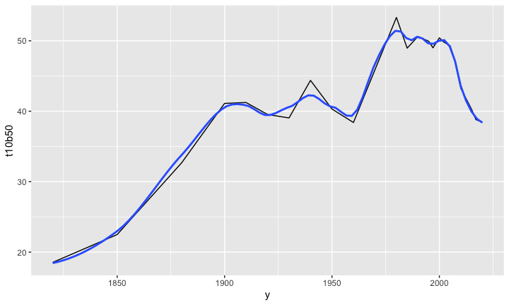

```r
df_f5 %>% ggplot(aes(x = y, y = t10b50)) + geom_line() + geom_smooth(span=0.25, se=FALSE)
```

### F9: Average annual wealth growth rate, 1995-2021 - fit curve + alpha

```r
df_f9 <- read_excel("./data/WIR2022s.xlsx", sheet = "data-F9"); df_f9
```

| p | Wealth growth 1995-2021 |
| --- | --- |
| 0.000 | 0.03102311 |
| 1.000 | 0.03102311 |
| 2.000 | 0.03102311 |
| 3.000 | 0.03102311 |
| 4.000 | 0.03102311 |
| 5.000 | 0.03102311 |
| 6.000 | 0.03118334 |
| 7.000 | 0.03165223 |
| 8.000 | 0.03223753 |
| 9.000 | 0.03281050 |

[output cut: 117 more lines]

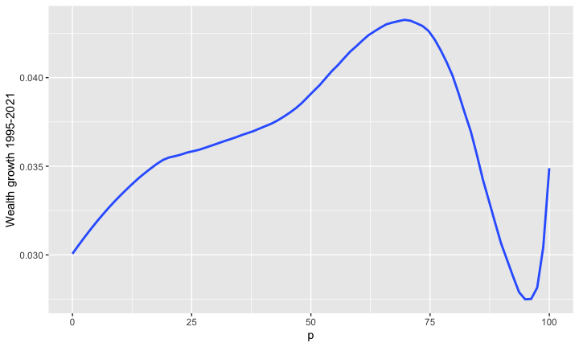

```r
df_f9 %>%
  ggplot(aes(x = p, y = `Wealth growth 1995-2021`)) + geom_smooth(span = 0.30, se = FALSE)
```

### F7: Global income inequality, 1820-2020 - pivot + fit curve

```r
df_f7 <- read_excel("./data/WIR2022s.xlsx", sheet = "data-F7"); df_f7
```

| y | Bottom 50% | Middle 40% | Top 10% |
| --- | --- | --- | --- |
| 1820 | 0.13564739 | 0.3614602 | 0.5028924 |
| 1850 | 0.11820287 | 0.3501668 | 0.5316303 |
| 1880 | 0.08696501 | 0.3447726 | 0.5682624 |
| 1900 | 0.07241563 | 0.3321809 | 0.5954035 |
| 1910 | 0.07285886 | 0.3262064 | 0.6009347 |
| 1920 | 0.07546183 | 0.3277030 | 0.5968352 |
| 1930 | 0.07139124 | 0.3711047 | 0.5575041 |
| 1940 | 0.06286313 | 0.3791833 | 0.5579536 |
| 1950 | 0.06873786 | 0.3770968 | 0.5541653 |
| 1960 | 0.07008597 | 0.3916303 | 0.5382837 |

[output cut: 14 more lines]

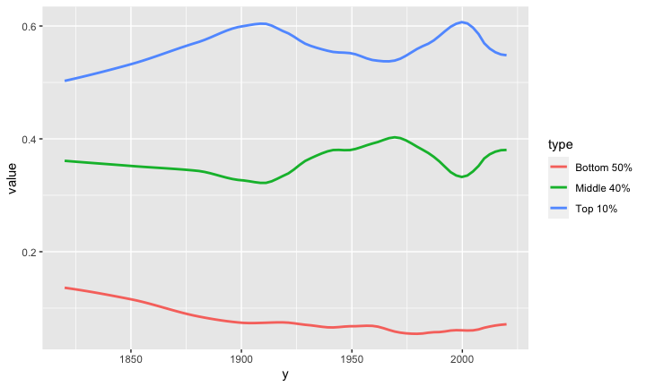

```r
df_f7 %>%
  pivot_longer(cols = 2:4, names_to = "type", values_to = "value") %>%
  ggplot(aes(x = y, y = value, color = type)) +
  stat_smooth(formula = y~x, method = "loess", span = 0.25, se = FALSE)
```

### F10: The share of wealth owned by the global 0.1% and billionaires, 2021 - pivot + fit curve

```r
df_f10 <- read_excel("./data/WIR2022s.xlsx", sheet = "data-F10"); df_f10
```

| year | bn_hhweal | top0.1_hhweal | ...4 | ...5 | ...6 |
| --- | --- | --- | --- | --- | --- |
| 1995 | 0.010817260 | 0.0729 | NA | NA | NA |
| 1996 | 0.011425801 | 0.0744 | NA | NA | NA |
| 1997 | 0.010075037 | 0.0768 | NA | NA | NA |
| 1998 | 0.009947428 | 0.0815 | NA | NA | NA |
| 1999 | 0.011193804 | 0.0855 | NA | NA | NA |
| 2000 | 0.011535854 | 0.0862 | NA | NA | NA |
| 2001 | 0.013913389 | 0.0846 | NA | NA | NA |
| 2002 | 0.011883716 | 0.0800 | NA | NA | NA |
| 2003 | 0.010289773 | 0.0800 | NA | NA | NA |
| 2004 | 0.012676390 | 0.0828 | NA | NA | NA |

[output cut: 17 more lines]

```r
df_f10 %>%
  select(year, "Global Billionaire Wealth" = bn_hhweal, "Top 0.01%" = top0.1_hhweal) %>%
  pivot_longer(!year, names_to = "group",".value", values_to = "value")
```

| year | group | value |
| --- | --- | --- |
| 1995 | Global Billionaire Wealth | 0.010817260 |
| 1995 | Top 0.01% | 0.072900000 |
| 1996 | Global Billionaire Wealth | 0.011425801 |
| 1996 | Top 0.01% | 0.074400000 |
| 1997 | Global Billionaire Wealth | 0.010075037 |
| 1997 | Top 0.01% | 0.076800000 |
| 1998 | Global Billionaire Wealth | 0.009947428 |
| 1998 | Top 0.01% | 0.081500000 |
| 1999 | Global Billionaire Wealth | 0.011193804 |
| 1999 | Top 0.01% | 0.085500000 |

[output cut: 44 more lines]

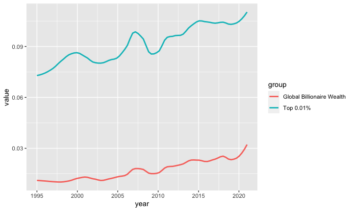

```r
df_f10 %>%
  select(year, "Global Billionaire Wealth" = bn_hhweal, "Top 0.01%" = top0.1_hhweal) %>%
  pivot_longer(!year, names_to = "group",".value", values_to = "value") %>%
  ggplot() +
  stat_smooth(aes(x = year, y = value, color = group), formula = y~x, method = "loess", span = 0.25, se = FALSE)
```

### F6: Global income inequality: Between vs. Within country inequality (Theil index), 1820-2020 - pivot + area

```r
df_f6 <- read_excel("./data/WIR2022s.xlsx", sheet = "data-F6"); df_f6
```

| ...1 | Between-country inequality | Within-country inequality |
| --- | --- | --- |
| 1820 | 0.1202971 | 0.8797029 |
| 1850 | 0.1664352 | 0.8335648 |
| 1880 | 0.2410592 | 0.7589408 |
| 1900 | 0.2565747 | 0.7434253 |
| 1920 | 0.3203289 | 0.6796711 |
| 1950 | 0.4391636 | 0.5608364 |
| 1980 | 0.5686893 | 0.4313107 |
| 2000 | 0.4734622 | 0.5265378 |
| 2020 | 0.3200879 | 0.6799121 |

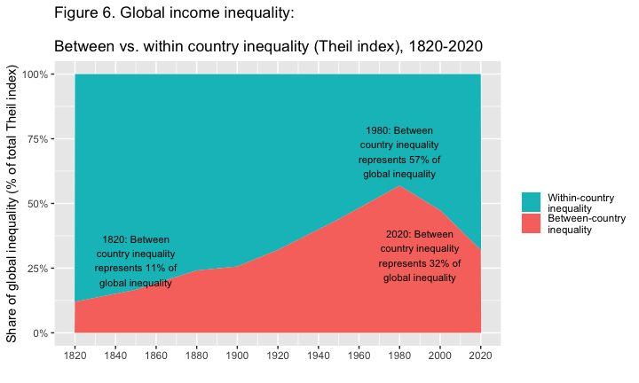

```r
df_f6 %>% select(year = "...1", 2:3) %>%
  pivot_longer(cols = 2:3, names_to = "type", values_to = "value") %>%
  mutate(types = factor(type,
      levels = c("Within-country inequality", "Between-country inequality"))) %>%
  ggplot(aes(x = year, y = value, fill = types)) +
  geom_area() +
  scale_y_continuous(labels = scales::percent_format(accuracy = 1)) +
  scale_x_continuous(breaks = round(seq(1820, 2020, by = 20),1)) +
  scale_fill_manual(values=rev(scales::hue_pal()(2)),
      labels = function(x) str_wrap(x, width = 15)) +
  labs(title = "Figure 6. Global income inequality:
       \nBetween vs. within country inequality (Theil index), 1820-2020",
       x = "", y = "Share of global inequality (% of total Theil index)", fill = "") +
  annotate("text", x = 1850, y = 0.28,
      label = stringr::str_wrap("1820: Between country inequality represents 11%
                                of global inequality", width = 20), size = 3) +
  annotate("text", x = 1980, y = 0.70,
      label = stringr::str_wrap("1980: Between country inequality represents 57%
                                of global inequality", width = 20), size = 3) +
  annotate("text", x = 1990, y = 0.30,
      label = stringr::str_wrap("2020: Between country inequality represents 32%
                                of global inequality", width = 20), size = 3)
```

### F11: Top 1% vs bottom 50% wealth shares in Western Europe and the US, 1910-2020 - pivot name_sep + fit curve

```r
df_f11 <- read_excel("./data/WIR2022s.xlsx", sheet = "data-F11"); df_f11
```

| year | USbot50 | UStop1 | EUbot50 | EUtop1 |
| --- | --- | --- | --- | --- |
| 1910 | 0.007000000 | 0.4254405 | 0.01279333 | 0.5543653 |
| 1920 | 0.010233268 | 0.4095210 | 0.01393704 | 0.4960562 |
| 1930 | 0.007371547 | 0.4091269 | 0.01746296 | 0.4636822 |
| 1940 | 0.011213015 | 0.3185391 | 0.02824333 | 0.4116194 |
| 1950 | 0.027012533 | 0.2760278 | 0.02716333 | 0.3388022 |
| 1960 | 0.023194874 | 0.2787299 | 0.05026667 | 0.3044353 |
| 1970 | 0.022070000 | 0.2408800 | 0.06493667 | 0.2349556 |
| 1980 | 0.026040001 | 0.2512800 | 0.06583333 | 0.2004263 |
| 1990 | 0.021070000 | 0.2939800 | 0.05354417 | 0.1996896 |
| 2000 | 0.016200000 | 0.3228200 | 0.05428167 | 0.2144617 |

[output cut: 2 more lines]

```r
df_f11 %>%
  rename(!year, US_bot50 = USbot50, US_top1 = UStop1,
         EU_bot50 = EUbot50, EU_top1 = EUtop1) %>%
  pivot_longer(!year, names_to = c("group",".value"), names_sep = "_") %>%
  pivot_longer(3:4, names_to = "type", values_to = "value") %>%
  ggplot() +
  stat_smooth(aes(x = year, y = value, color = group, linetype = type),
              span = 0.25, se = FALSE) +
  scale_x_continuous(breaks = round(seq(1910, 2020, by = 10),1)) +
  scale_y_continuous(labels = scales::percent_format(accuracy = 1)) +
  labs(title = "Figure 11. Top 1% vs bottom 50% wealth shares
       \n in Western Europe and the US, 1910-2020",
       x = "", y = "Share of total personal wealth (%)", color = "", linetype = "") +
  scale_linetype_manual(values = c("dotted","solid")) +
  annotate("text", x = 2000, y = 0.50,
      label = stringr::str_wrap("Wealth inequality has been rising at
        different speeds after a historical decline. The bottom 50% has always been
                                extremely low.", width = 30), size = 3)
```

#### Step 1.

```r
df_f11 %>% rename(!year, US_bot50 = USbot50, US_top1 = UStop1,
                  EU_bot50 = EUbot50, EU_top1 = EUtop1)
```

| year | US_bot50 | US_top1 | EU_bot50 | EU_top1 |
| --- | --- | --- | --- | --- |
| 1910 | 0.007000000 | 0.4254405 | 0.01279333 | 0.5543653 |
| 1920 | 0.010233268 | 0.4095210 | 0.01393704 | 0.4960562 |
| 1930 | 0.007371547 | 0.4091269 | 0.01746296 | 0.4636822 |
| 1940 | 0.011213015 | 0.3185391 | 0.02824333 | 0.4116194 |
| 1950 | 0.027012533 | 0.2760278 | 0.02716333 | 0.3388022 |
| 1960 | 0.023194874 | 0.2787299 | 0.05026667 | 0.3044353 |
| 1970 | 0.022070000 | 0.2408800 | 0.06493667 | 0.2349556 |
| 1980 | 0.026040001 | 0.2512800 | 0.06583333 | 0.2004263 |
| 1990 | 0.021070000 | 0.2939800 | 0.05354417 | 0.1996896 |
| 2000 | 0.016200000 | 0.3228200 | 0.05428167 | 0.2144617 |

[output cut: 2 more lines]

#### Step 2.

```r
df_f11 %>%
  rename(!year, US_bot50 = USbot50, US_top1 = UStop1,
         EU_bot50 = EUbot50, EU_top1 = EUtop1) %>%
  pivot_longer(!year, names_to = c("group",".value"), names_sep = "_")
```

#### Step 2.

| year | group | bot50 | top1 |
| --- | --- | --- | --- |
| 1910 | US | 0.007000000 | 0.4254405 |
| 1910 | EU | 0.012793333 | 0.5543653 |
| 1920 | US | 0.010233268 | 0.4095210 |
| 1920 | EU | 0.013937037 | 0.4960562 |
| 1930 | US | 0.007371547 | 0.4091269 |
| 1930 | EU | 0.017462963 | 0.4636822 |
| 1940 | US | 0.011213015 | 0.3185391 |
| 1940 | EU | 0.028243333 | 0.4116194 |
| 1950 | US | 0.027012533 | 0.2760278 |
| 1950 | EU | 0.027163332 | 0.3388022 |

[output cut: 14 more lines]

#### Step 3.

```r
df_f11 %>%
  rename(!year, US_bot50 = USbot50, US_top1 = UStop1,
         EU_bot50 = EUbot50, EU_top1 = EUtop1) %>%
  pivot_longer(!year, names_to = c("group",".value"),
               names_sep = "_") %>%
  pivot_longer(3:4, names_to = "type", values_to = "value")
```

#### Step 3.

| year | group | type | value |
| --- | --- | --- | --- |
| 1910 | US | bot50 | 0.007000000 |
| 1910 | US | top1 | 0.425440520 |
| 1910 | EU | bot50 | 0.012793333 |
| 1910 | EU | top1 | 0.554365277 |
| 1920 | US | bot50 | 0.010233268 |
| 1920 | US | top1 | 0.409521013 |
| 1920 | EU | bot50 | 0.013937037 |
| 1920 | EU | top1 | 0.496056229 |
| 1930 | US | bot50 | 0.007371547 |
| 1930 | US | top1 | 0.409126878 |

[output cut: 38 more lines]

[figure not shown]

### F8: The rise of private versus the decline of public wealth in rich countries, 1970-2020 - rename + pivot + pivot + fit curve

```r
df_f8 <- read_excel("./data/WIR2022s.xlsx", sheet = "data-F8"); df_f8
```

| year | Germany | Germany (private) | Spain | Spain (private) | France | France (private) | UK | UK (private) | Japan | Japan (private) | Norway | Norway (private) | USA | USA (private) | gwealAVGRICH | pwealAVGRICH |
| --- | --- | --- | --- | --- | --- | --- | --- | --- | --- | --- | --- | --- | --- | --- | --- | --- |
| 1970 | 1.1116530 | 2.298287 | 0.6038899 | 4.061005 | 0.4216273 | 3.120332 | 0.60128810 | 2.849942 | 0.71940960 | 3.092434 | NA | NA | 0.36390920 | 3.264223 | 0.6369629 | 3.114371 |
| 1971 | 1.1170860 | 2.248584 | 0.6569503 | 4.531124 | 0.4426854 | 3.057913 | 0.68890840 | 2.856148 | 0.78210390 | 3.356449 | NA | NA | 0.38012850 | 3.261986 | 0.6779771 | 3.218701 |
| 1972 | 1.1143400 | 2.267685 | 0.6244062 | 4.356174 | 0.4668727 | 3.082564 | 0.78986150 | 2.944858 | 0.84188520 | 3.847256 | NA | NA | 0.37432040 | 3.340595 | 0.7019477 | 3.306522 |
| 1973 | 1.1066390 | 2.233598 | 0.5957342 | 4.460879 | 0.4781224 | 3.062226 | 0.92906140 | 2.916999 | 0.89474570 | 4.158962 | NA | NA | 0.40660970 | 3.247478 | 0.7351521 | 3.346690 |
| 1974 | 1.1332370 | 2.252788 | 0.5860708 | 4.641235 | 0.4979704 | 3.034183 | 1.08790600 | 2.942605 | 0.93590400 | 3.983348 | NA | NA | 0.50054130 | 3.072135 | 0.7902716 | 3.321049 |
| 1975 | 1.1155300 | 2.350618 | 0.6017208 | 4.826020 | 0.5450546 | 3.119721 | 1.00039000 | 2.651910 | 0.94407140 | 3.832413 | NA | NA | 0.52876290 | 3.057138 | 0.7892550 | 3.306303 |
| 1976 | 1.0339160 | 2.341541 | 0.5807208 | 4.460111 | 0.5613294 | 3.077914 | 0.91778720 | 2.536953 | 0.90228480 | 3.754025 | NA | NA | 0.48457710 | 3.111119 | 0.7467692 | 3.213610 |
| 1977 | 1.0051520 | 2.421246 | 0.5855834 | 4.097454 | 0.5674292 | 3.098735 | 0.86698500 | 2.467270 | 0.87971750 | 3.736542 | NA | NA | 0.47339750 | 3.096011 | 0.7297108 | 3.152876 |
| 1978 | 0.9895794 | 2.517136 | 0.6040155 | 4.099272 | 0.5800219 | 3.198225 | 0.88060180 | 2.514017 | 0.85960620 | 3.801498 | NA | NA | 0.47283040 | 3.052021 | 0.7311092 | 3.197028 |
| 1979 | 0.9889561 | 2.547218 | 0.6211699 | 4.203296 | 0.6241281 | 3.297995 | 0.95529160 | 2.618359 | 0.88377380 | 4.094389 | NA | NA | 0.51814040 | 3.152546 | 0.7652433 | 3.318967 |

[output cut: 41 more lines]

```r
df_f8 %>%
  select(year, Germany_public = Germany, Germany_private = 'Germany (private)',
         Spain_public = Spain, Spain_private = 'Spain (private)',
         France_public = France, France_private = 'France (private)',
         UK_public  = UK, UK_private = 'UK (private)',
         Japan_public = Japan, Japan_private = 'Japan (private)',
         Norway_public = Norway, Norway_private = 'Norway (private)',
         USA_public = USA, USA_private = 'USA (private)') %>%
  pivot_longer(!year, names_to = c("country",".value"), names_sep = "_") %>%
  pivot_longer(3:4, names_to = "type", values_to = "value") %>%
  ggplot() +
  stat_smooth(aes(x = year, y = value, color = country, linetype = type),
              span = 0.25, se = FALSE, size=0.75) +
  scale_y_continuous(labels = scales::percent_format(accuracy = 1)) +
  labs(title = "Figure 8. The rise of private versus the decline of public
       wealth in rich countries, 1970-2020",
       x = "", y = "wealth as as % of national income", color = "", type = "")
```

#### Step 1

```r
df_f8 %>%
  select(year, Germany_public = Germany, Germany_private = 'Germany (private)',
         Spain_public = Spain, Spain_private = 'Spain (private)',
         France_public = France, France_private = 'France (private)',
         UK_public  = UK, UK_private = 'UK (private)',
         Japan_public = Japan, Japan_private = 'Japan (private)',
         Norway_public = Norway, Norway_private = 'Norway (private)',
         USA_public = USA, USA_private = 'USA (private)')
```

| year | Germany_public | Germany_private | Spain_public | Spain_private | France_public | France_private | UK_public | UK_private | Japan_public | Japan_private | Norway_public | Norway_private | USA_public | USA_private |
| --- | --- | --- | --- | --- | --- | --- | --- | --- | --- | --- | --- | --- | --- | --- |
| 1970 | 1.1116530 | 2.298287 | 0.6038899 | 4.061005 | 0.4216273 | 3.120332 | 0.60128810 | 2.849942 | 0.71940960 | 3.092434 | NA | NA | 0.36390920 | 3.264223 |
| 1971 | 1.1170860 | 2.248584 | 0.6569503 | 4.531124 | 0.4426854 | 3.057913 | 0.68890840 | 2.856148 | 0.78210390 | 3.356449 | NA | NA | 0.38012850 | 3.261986 |
| 1972 | 1.1143400 | 2.267685 | 0.6244062 | 4.356174 | 0.4668727 | 3.082564 | 0.78986150 | 2.944858 | 0.84188520 | 3.847256 | NA | NA | 0.37432040 | 3.340595 |
| 1973 | 1.1066390 | 2.233598 | 0.5957342 | 4.460879 | 0.4781224 | 3.062226 | 0.92906140 | 2.916999 | 0.89474570 | 4.158962 | NA | NA | 0.40660970 | 3.247478 |
| 1974 | 1.1332370 | 2.252788 | 0.5860708 | 4.641235 | 0.4979704 | 3.034183 | 1.08790600 | 2.942605 | 0.93590400 | 3.983348 | NA | NA | 0.50054130 | 3.072135 |
| 1975 | 1.1155300 | 2.350618 | 0.6017208 | 4.826020 | 0.5450546 | 3.119721 | 1.00039000 | 2.651910 | 0.94407140 | 3.832413 | NA | NA | 0.52876290 | 3.057138 |
| 1976 | 1.0339160 | 2.341541 | 0.5807208 | 4.460111 | 0.5613294 | 3.077914 | 0.91778720 | 2.536953 | 0.90228480 | 3.754025 | NA | NA | 0.48457710 | 3.111119 |
| 1977 | 1.0051520 | 2.421246 | 0.5855834 | 4.097454 | 0.5674292 | 3.098735 | 0.86698500 | 2.467270 | 0.87971750 | 3.736542 | NA | NA | 0.47339750 | 3.096011 |
| 1978 | 0.9895794 | 2.517136 | 0.6040155 | 4.099272 | 0.5800219 | 3.198225 | 0.88060180 | 2.514017 | 0.85960620 | 3.801498 | NA | NA | 0.47283040 | 3.052021 |
| 1979 | 0.9889561 | 2.547218 | 0.6211699 | 4.203296 | 0.6241281 | 3.297995 | 0.95529160 | 2.618359 | 0.88377380 | 4.094389 | NA | NA | 0.51814040 | 3.152546 |

[output cut: 41 more lines]

#### Step 2.

```r
df_f8 %>%
  select(year, Germany_public = Germany, Germany_private = 'Germany (private)',
         Spain_public = Spain, Spain_private = 'Spain (private)',
         France_public = France, France_private = 'France (private)',
         UK_public  = UK, UK_private = 'UK (private)',
         Japan_public = Japan, Japan_private = 'Japan (private)',
         Norway_public = Norway, Norway_private = 'Norway (private)',
         USA_public = USA, USA_private = 'USA (private)') %>%
  pivot_longer(!year, names_to = c("country",".value"), names_sep = "_")
```

| year | country | public | private |
| --- | --- | --- | --- |
| 1970 | Germany | 1.11165300 | 2.2982870 |
| 1970 | Spain | 0.60388990 | 4.0610050 |
| 1970 | France | 0.42162730 | 3.1203320 |
| 1970 | UK | 0.60128810 | 2.8499420 |
| 1970 | Japan | 0.71940960 | 3.0924340 |
| 1970 | Norway | NA | NA |
| 1970 | USA | 0.36390920 | 3.2642230 |
| 1971 | Germany | 1.11708600 | 2.2485840 |
| 1971 | Spain | 0.65695030 | 4.5311240 |
| 1971 | France | 0.44268540 | 3.0579130 |

[output cut: 347 more lines]

#### Step 3.

```r
df_f8 %>%
  select(year, Germany_public = Germany, Germany_private = 'Germany (private)',
         Spain_public = Spain, Spain_private = 'Spain (private)',
         France_public = France, France_private = 'France (private)',
         UK_public  = UK, UK_private = 'UK (private)',
         Japan_public = Japan, Japan_private = 'Japan (private)',
         Norway_public = Norway, Norway_private = 'Norway (private)',
         USA_public = USA, USA_private = 'USA (private)') %>%
  pivot_longer(!year, names_to = c("country",".value"), names_sep = "_") %>%
  pivot_longer(3:4, names_to = "type", values_to = "value")
```

| year | country | type | value |
| --- | --- | --- | --- |
| 1970 | Germany | public | 1.11165300 |
| 1970 | Germany | private | 2.29828700 |
| 1970 | Spain | public | 0.60388990 |
| 1970 | Spain | private | 4.06100500 |
| 1970 | France | public | 0.42162730 |
| 1970 | France | private | 3.12033200 |
| 1970 | UK | public | 0.60128810 |
| 1970 | UK | private | 2.84994200 |
| 1970 | Japan | public | 0.71940960 |
| 1970 | Japan | private | 3.09243400 |

[output cut: 704 more lines]

#### Step 3. Final Step

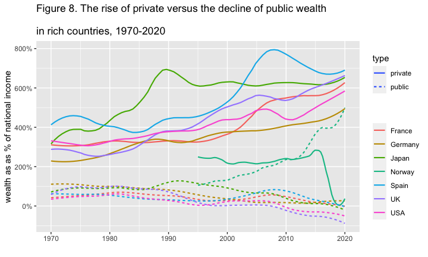

```r
df_f8 %>%
  select(year, Germany_public = Germany, Germany_private = 'Germany (private)',
         Spain_public = Spain, Spain_private = 'Spain (private)',
         France_public = France, France_private = 'France (private)',
         UK_public  = UK, UK_private = 'UK (private)',
         Japan_public = Japan, Japan_private = 'Japan (private)',
         Norway_public = Norway, Norway_private = 'Norway (private)',
         USA_public = USA, USA_private = 'USA (private)') %>%
  pivot_longer(!year, names_to = c("country",".value"), names_sep = "_") %>%
  pivot_longer(3:4, names_to = "type", values_to = "value") %>%
  ggplot() +
  stat_smooth(aes(x = year, y = value, color = country, linetype = type),
              formula = y~x, method = "loess", span = 0.25, se = FALSE, size=0.75) +
  scale_y_continuous(labels = scales::percent_format(accuracy = 1)) +
  labs(title = "Figure 8. The rise of private versus the decline of public wealth
       \nin rich countries, 1970-2020",
       x = "", y = "wealth as as % of national income", color = "", type = "")
```

### F15: Per capita emissions acriss the world, 2019 - add row names + dodge

```r
df_f15 <- read_excel("./data/WIR2022s.xlsx", sheet = "data-F15"); df_f15
```

| regionWID | group | tcap | mark |
| --- | --- | --- | --- |
| East Asia | Bottom 50% | 3.1186423 | 1 |
| NA | Middle 40% | 7.9053422 | 1 |
| NA | Top 10% | 38.9214325 | 1 |
| Europe | Bottom 50% | 5.0919490 | 2 |
| NA | Middle 40% | 10.6416652 | 2 |
| NA | Top 10% | 29.1887054 | 2 |
| North America | Bottom 50% | 9.6736345 | 3 |
| NA | Middle 40% | 21.6508063 | 3 |
| NA | Top 10% | 72.9800415 | 3 |
| South & South-East Asia | Bottom 50% | 1.0377777 | 4 |

[output cut: 14 more lines]

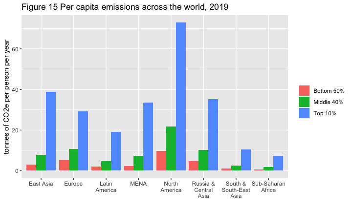

```r
df_f15 %>% mutate(region = rep(regionWID[!is.na(regionWID)], each = 3)) %>%
  select(region, group, tcap) %>%
  ggplot(aes(x = region, y = tcap, fill = group)) +
  geom_col(position = "dodge") +
  scale_x_discrete(labels = function(x) stringr::str_wrap(x, width = 10)) +
  labs(title = "Figure 15 Per capita emissions across the world, 2019",
       x = "", y = "tonnes of CO2e per person per year", fill = "")
```

## EDA Workflow

### EDA Step 0

1. Choose and clarify a topic to study.
2. List questions to study
3. Find data:
- link to data with a url: universal resource locator in a webpage
- download data in csv, Excel, etc.

Repeat the process during your EDA.

### EDA by R Studio: Step 1

In RStudio,

1.1. Project

- Create a new project: File > New Project; or
- Open a project: File > Open Project, Open Project in New Session, Open Recent Project
  - It is easier to find an existing project from: File > Recent Project
- *Check there is a file `project_name.Rproj` in your project folder (directory)*

1.2. data folder (directory) `data`

- Create a data folder: Press New Folder at the right bottom pane; or
- Confirm the data folder previously created: Press Files at the right bottom pane
- *If you follow 1, the data folder exists in your project folder*

1.3. Move (or copy) data for the project to the data folder

- If you downloaded the data, it is in your Download folder. Move it to `data`.
- *Check in your RStudio that your data is in `data`: Press Files at the right bottom pane and click `data`, the data folder.*

### EDA by R Studio: Step 2

2.1. Project Notebook: Memo

- Create an R Notebook: File > New File > R Notebook
  - You can use R Notebook template in Moodle by moving the template (template.Rmd or template.nb.Rmd) file in your project folder or copy and paste the text file into your new R Notebook.
  - If you use template.nb.Rmd (R Notebook File), choose Open in Editor.
- Add descriptive title.

2.2. Setup Code Chunk

- Create a code chunk and add packages to use in the project and RUN the code.
  - library(tidyverse)
  - library(WDI)
  - or any other packages

2.3. Choose `Source` or `Visual` editor mode, and start editing Project Notebook

- Set up Headings such as: About, Data, Analysis and Visualizations, Conclusions
- Under About or Data, paste url of the sites and/or the data
  - eg. World Development Indicator: https://datatopics.worldbank.org/world-development-indicators/)
  - eg. Public expenditure on education: https://data.un.org/_Docs/SYB/CSV/SYB65_245_202209_Public% 20expenditure%20on%20education.csv)

2.4. Edit a new file by saving as for a report

- File > Save As…

### EDA by R Studio: Step 3 - Importing Data

Assign a name you can recall easily when you import data. You may need to reload the data with options.

3.1. Use a package:

- WDI, wir, eurostat, etc/
- `wdi_shortname <- WDI(indicator = “indicator’s name”, … )
- Store the data and use it: `write_csv(wdi_shortname, "./data/wdi_shortname.csv")`
- `wdi_shortname <- read_csv("./data/wdi_shortname.csv")`

3.2. Use `readr` to read from `data`, your data folder

- `df1_shortname <- read_csv("./data/file_name.csv")`

3.3. Use `readr` to read using the url of the data

- `df2_shortname <- read_csv("url_of_the_data")`
- Store the data and use it: `write_csv(df2_shortname, "./data/df2_shortname.csv")`
- `df2_shortname <- read_csv("./data/df2_shortname.csv")`

3.5. Use `readxl` to read Excel data. Add `library(readxl)` in the setup and run.

- `df4 <- read_excel("./data/file_name.xlsx", sheet = 1)`

References: Cheat Sheet - `readr`, [readr](https://readr.tidyverse.org), [readxl](https://readxl.tidyverse.org)

### EDA by R Studio: Step 4 - Data Trasnformation

4.1. Look at the data: suppose `df` is the data frame

- It is a good option to change into a tibble: `dt <- as_tibble(df)`
- `head(df)`, `str(df)`, `summary(df)`, `dt`, `glimpse(dt)`

4.2. Look at each variable

- categorical? numerical?
- factor? - [forcats](https://forcats.tidyverse.org)

4.3. Variation of each data: suppose `x1` is a column name.

- `df %>% ggplot() + geom_histogram(aes(x1), bins = 30)`
- `df %>% drop_na(x1)`: see the rows with a value in `x1`. If the value is NA, the row is not shown.
  - `df_wo_na <- df %>% drop_na(x1)` if you want to use only the rows without NA in `x1`

4.4. Use `dpylr` and `tidyr` to change column names, tidy data, and/or summarize data

- `rename`, `select`, `filter`, `arrange`, `mutate`, `pivot_longer()`, `pivot_wider()`, `group_by` and `summarize`

References: Cheat Sheet - `dplyr` and `tidyr`, [dplyr](https://dplyr.tidyverse.org), [tidyr](https://tidyr.tidyverse.org)

### EDA by R Studio: Step 5 - Visualize Data

5.1. In combination with Stap 4 - data transformation, try various data visualization.

- What type of variation occurs within my variables?
- What type of covariation occurs between my variables?

5.2. Keep a record of what you can observe by the visualization

5.3. Edit the list of questions by adding or polishing

5.4. Select several informative chart and add options

5.5. Look at examples from the textbooks or teaching site to have better visualization

References: Cheat Sheet - `ggplot2` [ggplot2](https://ggplot2.tidyverse.org), [ggplot2 book](https://ggplot2-book.org)

### EDA by R Studio: Step 6 - Conclusions and Questions for Further Study

1. EDA is an iterative cycle that helps you understand what your data says. When you do EDA, you:
2. Generate questions about your data
3. Search for answers by visualising, transforming, and/or modeling your data

Use what you learn to refine your questions and/or generate new questions

EDA is an important part of any data analysis. You can use EDA to make discoveries about the world; or you can use EDA to ensure the quality of your data, asking questions about whether the data meets your standards or not.

### Example: WDI

- Government expenditure on education, total (% of GDP)
  - https://data.worldbank.org/indicator/SE.XPD.TOTL.GD.ZS
- ID: SE.XPD.TOTL.GD.ZS

### Example: WIR2022

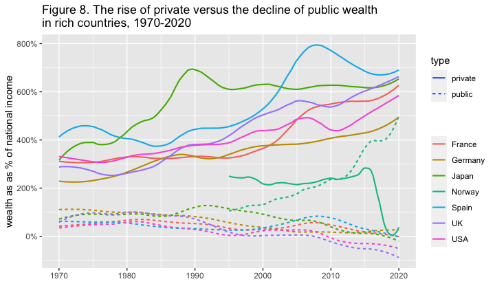

## The Week Five Assignment (in Moodle)

**`tidyr` and WIR2022**

- Create an R Notebook of a Data Analysis containing the following and submit the rendered HTML file (eg. `a3_123456.nb.html` by replacing 123456 with your ID)
  1. create an R Notebook using the R Notebook Template in Moodle, save as `a3_123456.Rmd`,
  2. write your name and ID and the contents,
  3. run each code block,
  4. preview to create `a3_123456.nb.html`,
  5. submit `a3_123456.nb.html` to Moodle.
1. Choose a data with at least two categorical variables and at least two numerical variables.
   - Information of the data: Name, Indicator, Description, Source, etc.
   - Explain why you chose the indicator
   - List questions you want to study
1. Explore the data using visualization using `ggplot2`
   - Create various charts
   - Create at least one chart with at least two categocial variables and at least one numerical variable.
   - Create at least one chart with at least two numerical variables and at least one categorical variable.
2. Observations based on your data visualization, and difficulties and questions encountered if any.

**Due:** 2023-01-23 23:59:00. Submit your R Notebook file in Moodle (The Fourth Assignment). Due on Monday!